# Pre-term R Introduction

Carole Voulgaris

8/10/2021

```r
library(spData)
library(sf)
library(tidyverse)
```

## Loading data

The `house` dataset is part of the spData package. It contains data on 25,357 single family homes sold in Lucas County, Ohio between 1993 and 1998, based on data from the county auditor (this data is taken from the James P. LeSage’s [Spatial Econometrics Toolbox for Matlab](https://www.spatial-econometrics.com/). The dataset includes the following variables:

- price: selling price
- yrbuilt: year built
- stories: one of seven values: one, bilevel, multilvl, one+half, two, two+half, or three
- TLA: total living area in square feet
- Wall: one of seven values: stucdrvt, ccbtile, metlvnyl, brick, stone, wood, partbrk
- beds: number of bedrooms
- baths number of full bathrooms
- halfbaths: number of half bathrooms
- frontage: frontage in feet
- depth: depth in feet
- garage: one of four values: no garage, basement, attached, detached, carport
- garagesqft: garage size in square feet, or zero for no garage
- rooms: number of rooms
- lotsize: lotsize in square feet
- sdate: sale date in format, yymmdd, e.g., Oct 17, 1997 = 971017
- avalue: auditor’s assessed value
- s1993: 1 indicated the home was sold in 1993, otherwise 0
- s1994: 1 indicated the home was sold in 1994, otherwise 0
- s1995: 1 indicated the home was sold in 1995, otherwise 0
- s1996: 1 indicated the home was sold in 1996, otherwise 0
- s1997: 1 indicated the home was sold in 1997, otherwise 0
- s1998: 1 indicated the home was sold in 1998, otherwise 0
- syear: Year the home was sold
- age: Age of the home in 1999, divided by 100

```r
homes <- st_as_sf(house)
```

## Using ggplot

The `ggplot` package is part of `tidyverse`, which was developed by Hadley Wickham. It offers a powerful set of tools for visualizing data, using an approach Wickham refers to as “a layered grammar of graphics,” which lets you create graphics using layers of commands.

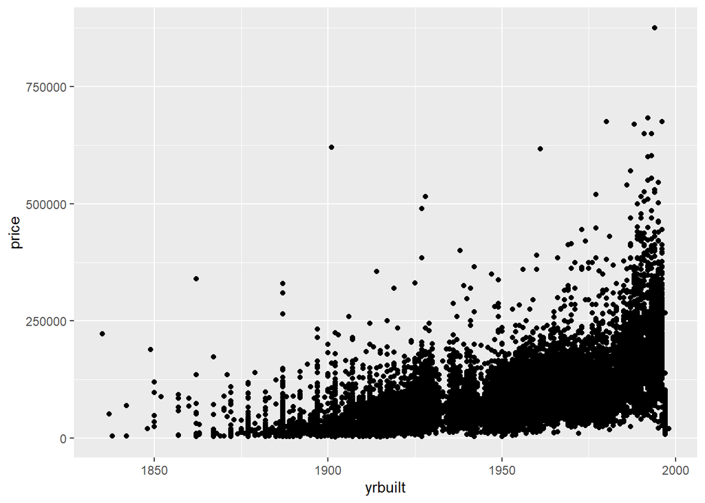

```r
ggplot() +
  geom_point(data = homes, aes(x = yrbuilt, y = price))
```